# ODP_Demo - 开放数据平台地理科学解决方案

[figure not shown]

**基于AWS开放数据的地理空间AI分析平台**

📚 中文文档 | 🚀 快速开始 | 🛠️ 功能特性 | 📖 使用指南

## 🌟 项目概述

ODP_Demo是一个综合性的地理科学解决方案包，集成了AWS开放数据平台、先进的AI图像分析技术和交互式地理可视化功能。项目通过18个精心设计的Jupyter notebook，展示了从基础地图创建到高级AI分析的完整工作流程。

### 🎯 核心价值

- **🌍 全球数据访问**: 集成Maxar、Planet、OpenAerialMap等多源卫星数据
- **🤖 AI驱动分析**: 基于SAM (Segment Anything Model) 的智能图像分割
- **💬 自然语言交互**: 支持文本提示的地理空间分析
- **📊 交互式可视化**: 基于Leafmap的动态地图和时序分析
- **🔧 即插即用**: 完整的AWS SageMaker部署方案

## 🛠️ 功能特性

### 📍 基础地理功能

- **交互式地图创建** - 多种底图源和自定义样式
- **数据可视化** - COG、STAC、WMS等多格式支持
- **空间分析** - 矢量数据处理和空间关系分析

### 🛰️ 多源数据集成

- **Maxar高分辨率影像** - 亚米级商业卫星数据
- **Planet日级监测** - 全球每日成像能力
- **开放航空地图** - 社区贡献的无人机影像
- **OpenStreetMap集成** - 矢量地理数据融合

### 🤖 AI图像分析

- **SAM自动分割** - 零样本图像分割技术
- **农业遥感应用** - 作物识别和长势监测
- **目标检测** - 建筑物、道路、水体等要素提取
- **变化检测** - 时序影像对比分析

### 💬 智能交互

- **文本提示分析** - 自然语言驱动的地理分析
- **批量处理** - 大规模自动化分析流程
- **专项应用** - 游泳池检测等特定目标识别

## 🚀 快速开始

### 环境要求

```bash
# 推荐环境配置
AWS SageMaker Instance: ml.g5.8xlarge
Platform: Amazon Linux 2, Jupyter Lab 4
Storage: 100GB EBS Volume
Python: 3.8+
CUDA: 11.0+ (用于AI功能)
```

### 一键部署

```bash
# 1. 克隆仓库
cd SageMaker
git clone https://github.com/ddipass/ODP_Demo.git
cd ODP_Demo

# 2. 快速部署环境
bash fast_deploy.sh

# 3. 启动Jupyter Lab
jupyter lab
```

### 核心依赖

```python
# 主要Python包
leafmap>=0.20.0      # 地理可视化
samgeo>=0.15.0       # SAM图像分割
geopandas>=0.13.0    # 地理数据处理
rasterio>=1.3.0      # 栅格数据处理
folium>=0.14.0       # 交互式地图
```

## 📖 使用指南

### 🎓 学习路径

#### 初学者路径

1. **地图创建基础** - 掌握交互式地图创建
2. **数据可视化** - 学习多源数据展示
3. **数据搜索** - 了解开放数据获取

#### 进阶用户路径

1. **SAM图像分割** - AI图像分析入门
2. **时序分析** - 动态变化监测
3. **文本提示** - 智能交互分析

#### 专业应用路径

1. **农业遥感** - 精准农业应用
2. **灾害监测** - 应急响应分析
3. **批量处理** - 大规模自动化

### 📁 项目结构

```
ODP_Demo/
├── 📓 Jupyter Notebooks (18个)
│   ├── 00_Demo_Features.ipynb          # 基础功能演示
│   ├── 01_ODP_Search.ipynb             # 数据搜索
│   ├── 07_SAM_AutoMask.ipynb           # AI图像分割
│   └── ...
├── 📚 docs/                            # 完整中文文档
│   ├── README.md                       # 文档总览
│   ├── 00_Demo_Features_地图创建功能详解.md
│   └── ...
├── 🖼️ images/                          # 示例图像
├── 📊 cache/                           # 数据缓存
├── 🔧 fast_deploy.sh                   # 快速部署脚本
└── 📄 README.md                        # 项目说明
```

## 🎨 功能展示

### 🤖 AI图像分割效果

*SAM模型在地理影像中的自动分割效果*

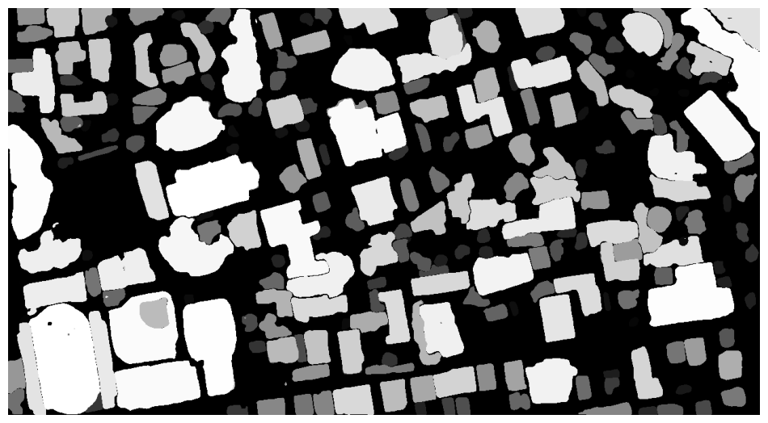

SAM自动分割示例

### 🌾 农业遥感应用

*精准农业中的作物识别和分析*

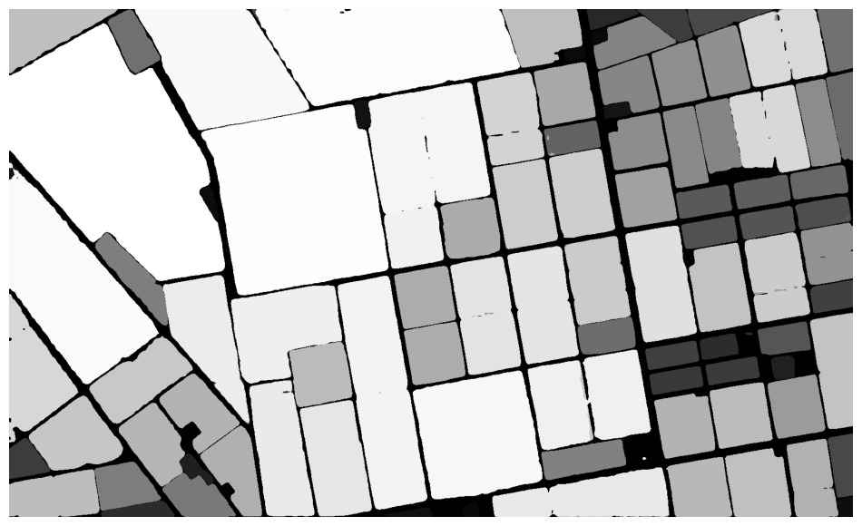

农业SAM应用

*农田分割和作物识别 - 支持精准农业管理*

### 💬 文本提示分析

*自然语言驱动的地理空间分析*

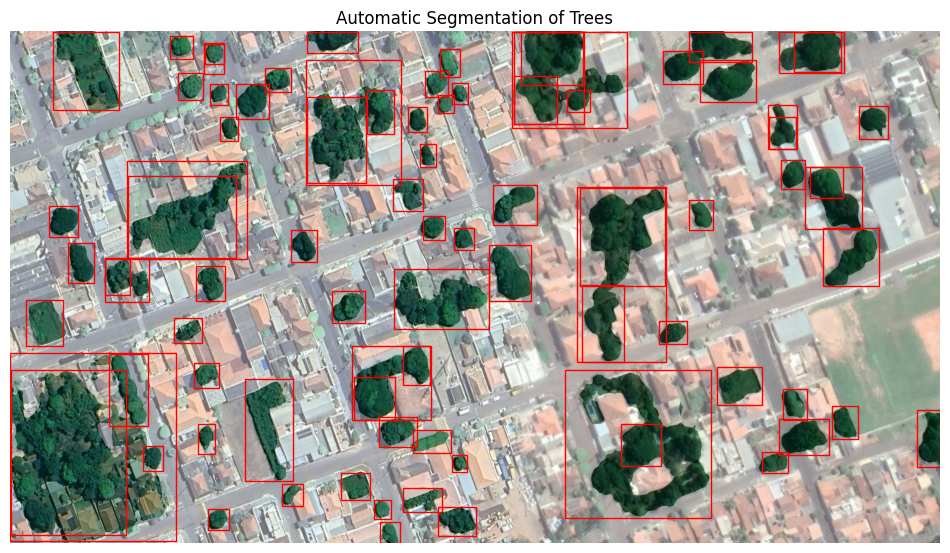

文本提示分析

*基于文本提示的智能地理分析*

### 🏊 专项目标检测

*游泳池检测等特定目标识别应用*

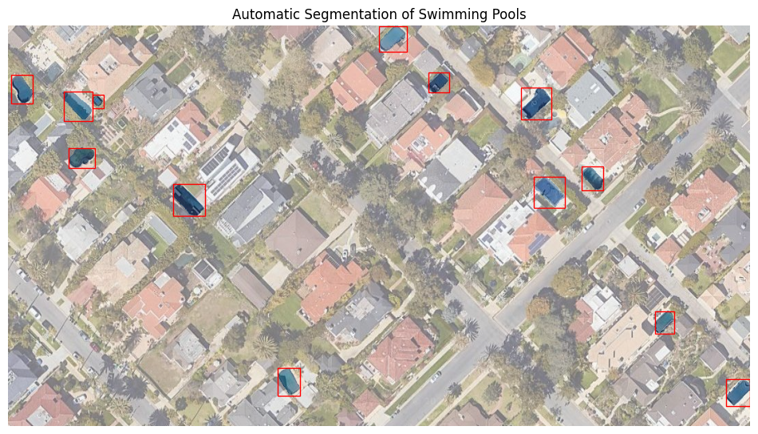

游泳池检测

*高精度游泳池自动检测 - 支持城市规划和房地产分析*

## 🔧 高级配置

### SageMaker环境设置

```python
# Jupyter Lab扩展检查
jupyter labextension list

# CUDA内存监控
conda install -c conda-forge nvitop
nvitop

# 磁盘空间检查
df -h
```

### 性能优化

```python
# GPU内存优化
import torch
torch.cuda.empty_cache()

# 数据缓存配置
import os
os.environ['GDAL_DISABLE_READDIR_ON_OPEN'] = 'EMPTY_DIR'
os.environ['CPL_VSIL_CURL_CACHE_SIZE'] = '200000000'
```

## 🤝 贡献指南

我们欢迎社区贡献！请查看以下方式参与项目：

- 🐛 **问题报告**: 在Issues中报告bug或提出功能请求
- 📝 **文档改进**: 帮助完善文档和示例
- 💻 **代码贡献**: 提交新功能或性能优化
- 🌍 **应用案例**: 分享您的应用场景和经验

## 📄 许可证

本项目采用 MIT License 开源协议。

## 🙏 致谢

- **AWS开放数据计划** - 提供丰富的地理空间数据资源
- **Meta SAM团队** - 革命性的图像分割技术
- **Leafmap社区** - 优秀的地理可视化工具
- **开源社区** - 各种优秀的Python地理空间库

**🌟 如果这个项目对您有帮助，请给我们一个Star！**

[figure not shown]

# 地理科学解决方案包 - 地图创建功能深度解析

## 功能概述

本文档详细解析`00_Demo_Features.ipynb`中的地图创建功能，包括每个参数的具体作用、调整效果、最佳实践和常见问题解决方案。

## 1. 基础地图创建 - leafmap.Map()

### 1.1 标准地图初始化

```python
m = leafmap.Map(center=(40, -100), zoom=4)
m.attribution_control = False
m
```

#### 参数深度解析

**center参数 - 地图中心点设置** - **数据类型**: 元组 (纬度, 经度) 或列表 [纬度, 经度] - **默认值**: (20, 0) - 非洲中部 - **示例值**: (40, -100) - 美国中部 - **取值范围**: - 纬度: -90 到 90 (南极到北极) - 经度: -180 到 180 (本初子午线为0)

**调整效果对比**:

```python
# 北京中心
m1 = leafmap.Map(center=(39.9042, 116.4074), zoom=10)

# 纽约中心
m2 = leafmap.Map(center=(40.7128, -74.0060), zoom=10)

# 悉尼中心
m3 = leafmap.Map(center=(-33.8688, 151.2093), zoom=10)
```

**zoom参数 - 缩放级别控制** - **数据类型**: 整数 - **默认值**: 2 - **取值范围**: 1-18 (部分地图服务支持到20+) - **级别说明**: - 1-3: 全球/大洲级别视图 - 4-6: 国家级别视图  
- 7-10: 省/州级别视图 - 11-14: 城市级别视图 - 15-18: 街道/建筑级别视图

**缩放级别效果对比**:

```python
# 全球视图 - 适合展示全球数据分布
m_global = leafmap.Map(center=(0, 0), zoom=2)

# 国家视图 - 适合国家级分析
m_country = leafmap.Map(center=(35, 105), zoom=4)  # 中国

# 城市视图 - 适合城市规划
m_city = leafmap.Map(center=(39.9042, 116.4074), zoom=10)  # 北京

# 街道视图 - 适合详细分析
m_street = leafmap.Map(center=(39.9042, 116.4074), zoom=15)  # 北京街道
```